# Risk Factor Analysis

## Outcome Variable

**Outcome Variable:** whz

## Predictor Variables

**Intervention Variable:** exclfeed6

**Adjustment Set:**

- arm
- sex
- brthmon
- W_mage
- meducyrs
- feducyrs
- hhwealth_quart
- hfoodsec
- W_mhtcm
- W_mwtkg
- W_mbmi
- vagbrth
- W_gagebrth
- W_birthwt
- W_birthlen
- W_nrooms
- W_nchldlt5
- month
- W_parity
- impfloor
- impsan
- safeh20
- delta_W_mage
- delta_meducyrs
- delta_feducyrs
- delta_hhwealth_quart
- delta_hfoodsec
- delta_W_mhtcm
- delta_W_mwtkg
- delta_W_mbmi
- delta_vagbrth
- delta_W_gagebrth
- delta_W_birthwt
- delta_W_birthlen
- delta_W_nrooms
- delta_W_nchldlt5
- delta_month
- delta_W_parity
- delta_impfloor
- delta_impsan
- delta_safeh20

## Stratifying Variables

The analysis was stratified on these variable(s):

- agecat
- studyid
- country

## Data Summary

| agecat | studyid | country | exclfeed6 | n_cell | n | outcome_variable |
| --- | --- | --- | --- | --- | --- | --- |
| Birth | CMC-V-BCS-2002 | INDIA | 1 | 7 | 7 | whz |
| Birth | CMC-V-BCS-2002 | INDIA | 0 | 0 | 7 | whz |
| Birth | EE | PAKISTAN | 1 | 24 | 28 | whz |
| Birth | EE | PAKISTAN | 0 | 4 | 28 | whz |
| Birth | GMS-Nepal | NEPAL | 1 | 390 | 522 | whz |
| Birth | GMS-Nepal | NEPAL | 0 | 132 | 522 | whz |
| Birth | IRC | INDIA | 1 | 0 | 12 | whz |
| Birth | IRC | INDIA | 0 | 12 | 12 | whz |
| Birth | JiVitA-3 | BANGLADESH | 1 | 8381 | 10744 | whz |
| Birth | JiVitA-3 | BANGLADESH | 0 | 2363 | 10744 | whz |
| Birth | JiVitA-4 | BANGLADESH | 1 | 1799 | 2224 | whz |
| Birth | JiVitA-4 | BANGLADESH | 0 | 425 | 2224 | whz |
| Birth | Keneba | GAMBIA | 1 | 450 | 1327 | whz |
| Birth | Keneba | GAMBIA | 0 | 877 | 1327 | whz |
| Birth | MAL-ED | BANGLADESH | 1 | 29 | 194 | whz |
| Birth | MAL-ED | BANGLADESH | 0 | 165 | 194 | whz |
| Birth | MAL-ED | BRAZIL | 1 | 1 | 57 | whz |
| Birth | MAL-ED | BRAZIL | 0 | 56 | 57 | whz |
| Birth | MAL-ED | INDIA | 1 | 1 | 37 | whz |
| Birth | MAL-ED | INDIA | 0 | 36 | 37 | whz |
| Birth | MAL-ED | NEPAL | 1 | 2 | 23 | whz |
| Birth | MAL-ED | NEPAL | 0 | 21 | 23 | whz |
| Birth | MAL-ED | PERU | 1 | 2 | 208 | whz |
| Birth | MAL-ED | PERU | 0 | 206 | 208 | whz |
| Birth | MAL-ED | SOUTH AFRICA | 1 | 0 | 90 | whz |
| Birth | MAL-ED | SOUTH AFRICA | 0 | 90 | 90 | whz |
| Birth | MAL-ED | TANZANIA, UNITED REPUBLIC OF | 1 | 0 | 105 | whz |
| Birth | MAL-ED | TANZANIA, UNITED REPUBLIC OF | 0 | 105 | 105 | whz |
| Birth | PROVIDE | BANGLADESH | 1 | 155 | 532 | whz |
| Birth | PROVIDE | BANGLADESH | 0 | 377 | 532 | whz |

[output cut: 70 more lines]

The following strata were considered:

- agecat: 24 months, studyid: CMC-V-BCS-2002, country: INDIA
- agecat: 24 months, studyid: EE, country: PAKISTAN
- agecat: 24 months, studyid: GMS-Nepal, country: NEPAL
- agecat: 24 months, studyid: IRC, country: INDIA
- agecat: 24 months, studyid: JiVitA-3, country: BANGLADESH
- agecat: 24 months, studyid: JiVitA-4, country: BANGLADESH
- agecat: 24 months, studyid: Keneba, country: GAMBIA
- agecat: 24 months, studyid: LCNI-5, country: MALAWI
- agecat: 24 months, studyid: MAL-ED, country: BANGLADESH
- agecat: 24 months, studyid: MAL-ED, country: BRAZIL
- agecat: 24 months, studyid: MAL-ED, country: INDIA
- agecat: 24 months, studyid: MAL-ED, country: NEPAL
- agecat: 24 months, studyid: MAL-ED, country: PERU
- agecat: 24 months, studyid: MAL-ED, country: SOUTH AFRICA
- agecat: 24 months, studyid: MAL-ED, country: TANZANIA, UNITED REPUBLIC OF
- agecat: 24 months, studyid: PROVIDE, country: BANGLADESH
- agecat: 6 months, studyid: CMC-V-BCS-2002, country: INDIA
- agecat: 6 months, studyid: EE, country: PAKISTAN
- agecat: 6 months, studyid: GMS-Nepal, country: NEPAL
- agecat: 6 months, studyid: IRC, country: INDIA
- agecat: 6 months, studyid: JiVitA-3, country: BANGLADESH
- agecat: 6 months, studyid: JiVitA-4, country: BANGLADESH
- agecat: 6 months, studyid: Keneba, country: GAMBIA
- agecat: 6 months, studyid: LCNI-5, country: MALAWI
- agecat: 6 months, studyid: MAL-ED, country: BANGLADESH
- agecat: 6 months, studyid: MAL-ED, country: BRAZIL
- agecat: 6 months, studyid: MAL-ED, country: INDIA
- agecat: 6 months, studyid: MAL-ED, country: NEPAL
- agecat: 6 months, studyid: MAL-ED, country: PERU
- agecat: 6 months, studyid: MAL-ED, country: SOUTH AFRICA
- agecat: 6 months, studyid: MAL-ED, country: TANZANIA, UNITED REPUBLIC OF
- agecat: 6 months, studyid: PROVIDE, country: BANGLADESH
- agecat: 6 months, studyid: SAS-CompFeed, country: INDIA
- agecat: 6 months, studyid: SAS-FoodSuppl, country: INDIA
- agecat: Birth, studyid: CMC-V-BCS-2002, country: INDIA
- agecat: Birth, studyid: EE, country: PAKISTAN
- agecat: Birth, studyid: GMS-Nepal, country: NEPAL
- agecat: Birth, studyid: IRC, country: INDIA
- agecat: Birth, studyid: JiVitA-3, country: BANGLADESH
- agecat: Birth, studyid: JiVitA-4, country: BANGLADESH
- agecat: Birth, studyid: Keneba, country: GAMBIA
- agecat: Birth, studyid: MAL-ED, country: BANGLADESH
- agecat: Birth, studyid: MAL-ED, country: BRAZIL
- agecat: Birth, studyid: MAL-ED, country: INDIA
- agecat: Birth, studyid: MAL-ED, country: NEPAL
- agecat: Birth, studyid: MAL-ED, country: PERU
- agecat: Birth, studyid: MAL-ED, country: SOUTH AFRICA
- agecat: Birth, studyid: MAL-ED, country: TANZANIA, UNITED REPUBLIC OF
- agecat: Birth, studyid: PROVIDE, country: BANGLADESH
- agecat: Birth, studyid: SAS-CompFeed, country: INDIA

### Dropped Strata

Some strata were dropped due to rare outcomes:

- agecat: Birth, studyid: CMC-V-BCS-2002, country: INDIA
- agecat: Birth, studyid: EE, country: PAKISTAN
- agecat: Birth, studyid: IRC, country: INDIA
- agecat: Birth, studyid: MAL-ED, country: BRAZIL
- agecat: Birth, studyid: MAL-ED, country: INDIA
- agecat: Birth, studyid: MAL-ED, country: NEPAL
- agecat: Birth, studyid: MAL-ED, country: PERU
- agecat: Birth, studyid: MAL-ED, country: SOUTH AFRICA
- agecat: Birth, studyid: MAL-ED, country: TANZANIA, UNITED REPUBLIC OF
- agecat: 6 months, studyid: CMC-V-BCS-2002, country: INDIA
- agecat: 6 months, studyid: IRC, country: INDIA
- agecat: 6 months, studyid: MAL-ED, country: INDIA
- agecat: 6 months, studyid: MAL-ED, country: SOUTH AFRICA
- agecat: 6 months, studyid: MAL-ED, country: TANZANIA, UNITED REPUBLIC OF
- agecat: 6 months, studyid: SAS-FoodSuppl, country: INDIA
- agecat: 24 months, studyid: CMC-V-BCS-2002, country: INDIA
- agecat: 24 months, studyid: EE, country: PAKISTAN
- agecat: 24 months, studyid: IRC, country: INDIA
- agecat: 24 months, studyid: MAL-ED, country: INDIA
- agecat: 24 months, studyid: MAL-ED, country: PERU
- agecat: 24 months, studyid: MAL-ED, country: SOUTH AFRICA
- agecat: 24 months, studyid: MAL-ED, country: TANZANIA, UNITED REPUBLIC OF

## Methods Detail

We’re interested in the causal parameters $E[Y_a]$ for all values of $a \in \mathcal{A}$. These parameters represent the mean outcome if, possibly contrary to fact, we intervened to set all units to have $A=a$. Under the randomization and positivity assumptions, these are identified by the statistical parameters $\psi_a=E_W[E_{Y|A,W}(Y|A=a,W)]$. In addition, we’re interested in the mean of $Y$, $E[Y]$ under no intervention (the observed mean). We will estimate these parameters by using SuperLearner to fit the relevant likelihood factors – $E_{Y|A,W}(Y|A=a,W)$ and $p(A=a|W)$, and then updating our likelihood fit using a joint TMLE.

For unadjusted analyses ($W=\{\}$), initial likelihoods were estimated using Lrnr_glm to estimate the simple $E(Y|A)$ and Lrnr_mean to estimate $p(A)$. For adjusted analyses, a small library containing Lrnr_glmnet, Lrnr_xgboost, and Lrnr_mean was used.

Having estimated these parameters, we will then use the delta method to estimate relative risks and attributable risks relative to a prespecified baseline level of $A$.

# Results Detail

## Results Plots

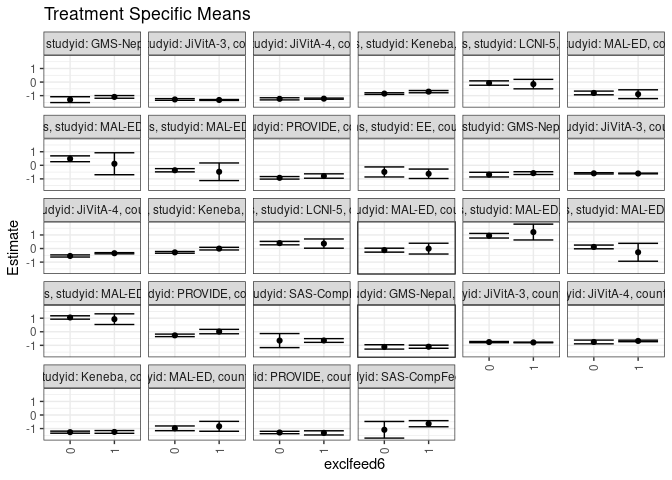

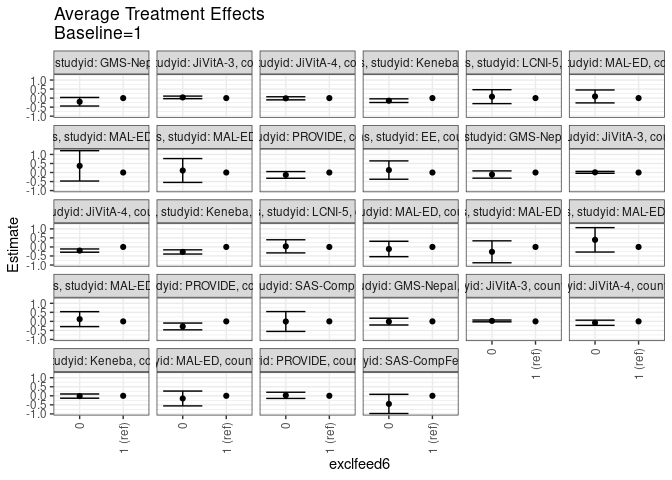

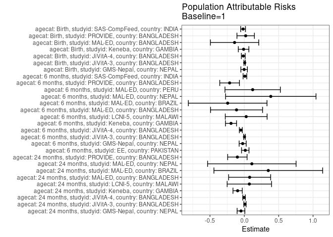

## Results Table

### Parameter: TSM

| agecat | studyid | country | intervention_level | baseline_level | estimate | ci_lower | ci_upper |
| --- | --- | --- | --- | --- | --- | --- | --- |
| Birth | GMS-Nepal | NEPAL | 1 | NA | -1.1038147 | -1.2170521 | -0.9905772 |
| Birth | GMS-Nepal | NEPAL | 0 | NA | -1.1164611 | -1.2773470 | -0.9555752 |
| Birth | JiVitA-3 | BANGLADESH | 1 | NA | -0.7865024 | -0.8113858 | -0.7616190 |
| Birth | JiVitA-3 | BANGLADESH | 0 | NA | -0.7605501 | -0.8044145 | -0.7166857 |
| Birth | JiVitA-4 | BANGLADESH | 1 | NA | -0.6753506 | -0.7304845 | -0.6202167 |
| Birth | JiVitA-4 | BANGLADESH | 0 | NA | -0.7523093 | -0.8895477 | -0.6150710 |
| Birth | Keneba | GAMBIA | 1 | NA | -1.2493975 | -1.3496505 | -1.1491445 |
| Birth | Keneba | GAMBIA | 0 | NA | -1.2656202 | -1.3419510 | -1.1892895 |
| Birth | MAL-ED | BANGLADESH | 1 | NA | -0.8336666 | -1.1988297 | -0.4685034 |
| Birth | MAL-ED | BANGLADESH | 0 | NA | -0.9812301 | -1.1543977 | -0.8080625 |
| Birth | PROVIDE | BANGLADESH | 1 | NA | -1.3183525 | -1.4711781 | -1.1655269 |
| Birth | PROVIDE | BANGLADESH | 0 | NA | -1.2914825 | -1.3799932 | -1.2029719 |
| Birth | SAS-CompFeed | INDIA | 1 | NA | -0.6419787 | -0.8661092 | -0.4178481 |
| Birth | SAS-CompFeed | INDIA | 0 | NA | -1.0901282 | -1.7027394 | -0.4775170 |
| 6 months | EE | PAKISTAN | 1 | NA | -0.6248062 | -0.9715960 | -0.2780164 |
| 6 months | EE | PAKISTAN | 0 | NA | -0.4893333 | -0.8590751 | -0.1195916 |
| 6 months | GMS-Nepal | NEPAL | 1 | NA | -0.5767848 | -0.6791376 | -0.4744320 |
| 6 months | GMS-Nepal | NEPAL | 0 | NA | -0.6879352 | -0.8595736 | -0.5162967 |
| 6 months | JiVitA-3 | BANGLADESH | 1 | NA | -0.6027244 | -0.6298535 | -0.5755952 |
| 6 months | JiVitA-3 | BANGLADESH | 0 | NA | -0.5925515 | -0.6381415 | -0.5469615 |
| 6 months | JiVitA-4 | BANGLADESH | 1 | NA | -0.3465234 | -0.3916388 | -0.3014080 |
| 6 months | JiVitA-4 | BANGLADESH | 0 | NA | -0.5476155 | -0.6255594 | -0.4696717 |
| 6 months | Keneba | GAMBIA | 1 | NA | -0.0064779 | -0.1045389 | 0.0915831 |
| 6 months | Keneba | GAMBIA | 0 | NA | -0.2824521 | -0.3449922 | -0.2199121 |
| 6 months | LCNI-5 | MALAWI | 1 | NA | 0.3653316 | 0.0251327 | 0.7055305 |
| 6 months | LCNI-5 | MALAWI | 0 | NA | 0.3989373 | 0.2722945 | 0.5255800 |
| 6 months | MAL-ED | BANGLADESH | 1 | NA | -0.0080668 | -0.4065359 | 0.3904023 |
| 6 months | MAL-ED | BANGLADESH | 0 | NA | -0.1201913 | -0.2657140 | 0.0253315 |
| 6 months | MAL-ED | BRAZIL | 1 | NA | 1.2144847 | 0.6301520 | 1.7988173 |
| 6 months | MAL-ED | BRAZIL | 0 | NA | 0.9453037 | 0.7757931 | 1.1148142 |
| 6 months | MAL-ED | NEPAL | 1 | NA | -0.2760000 | -0.9362767 | 0.3842767 |
| 6 months | MAL-ED | NEPAL | 0 | NA | 0.1178939 | -0.0200258 | 0.2558137 |
| 6 months | MAL-ED | PERU | 1 | NA | 0.9290000 | 0.5350705 | 1.3229295 |
| 6 months | MAL-ED | PERU | 0 | NA | 1.0529010 | 0.9277571 | 1.1780449 |
| 6 months | PROVIDE | BANGLADESH | 1 | NA | 0.0148076 | -0.1478617 | 0.1774770 |
| 6 months | PROVIDE | BANGLADESH | 0 | NA | -0.2650615 | -0.3594065 | -0.1707166 |
| 6 months | SAS-CompFeed | INDIA | 1 | NA | -0.6438016 | -0.7819173 | -0.5056859 |
| 6 months | SAS-CompFeed | INDIA | 0 | NA | -0.6500492 | -1.1672739 | -0.1328245 |
| 24 months | GMS-Nepal | NEPAL | 1 | NA | -1.0938986 | -1.1928826 | -0.9949146 |
| 24 months | GMS-Nepal | NEPAL | 0 | NA | -1.2964066 | -1.5120245 | -1.0807888 |
| 24 months | JiVitA-3 | BANGLADESH | 1 | NA | -1.3198137 | -1.3548328 | -1.2847946 |
| 24 months | JiVitA-3 | BANGLADESH | 0 | NA | -1.2814204 | -1.3432307 | -1.2196101 |
| 24 months | JiVitA-4 | BANGLADESH | 1 | NA | -1.2229576 | -1.2632482 | -1.1826670 |
| 24 months | JiVitA-4 | BANGLADESH | 0 | NA | -1.2356433 | -1.3134575 | -1.1578290 |
| 24 months | Keneba | GAMBIA | 1 | NA | -0.7059914 | -0.7885532 | -0.6234297 |
| 24 months | Keneba | GAMBIA | 0 | NA | -0.8493060 | -0.9108859 | -0.7877261 |
| 24 months | LCNI-5 | MALAWI | 1 | NA | -0.1502348 | -0.5002113 | 0.1997416 |
| 24 months | LCNI-5 | MALAWI | 0 | NA | -0.0718792 | -0.2327039 | 0.0889454 |
| 24 months | MAL-ED | BANGLADESH | 1 | NA | -0.8944685 | -1.2183153 | -0.5706216 |
| 24 months | MAL-ED | BANGLADESH | 0 | NA | -0.8020296 | -0.9383629 | -0.6656963 |
| 24 months | MAL-ED | BRAZIL | 1 | NA | 0.1138191 | -0.6958888 | 0.9235269 |
| 24 months | MAL-ED | BRAZIL | 0 | NA | 0.4816385 | 0.2667960 | 0.6964810 |
| 24 months | MAL-ED | NEPAL | 1 | NA | -0.4770000 | -1.1267115 | 0.1727115 |
| 24 months | MAL-ED | NEPAL | 0 | NA | -0.3648832 | -0.4833183 | -0.2464480 |
| 24 months | PROVIDE | BANGLADESH | 1 | NA | -0.7917925 | -0.9536323 | -0.6299527 |
| 24 months | PROVIDE | BANGLADESH | 0 | NA | -0.9245656 | -1.0188687 | -0.8302624 |

### Parameter: E(Y)

| agecat | studyid | country | intervention_level | baseline_level | estimate | ci_lower | ci_upper |
| --- | --- | --- | --- | --- | --- | --- | --- |
| Birth | GMS-Nepal | NEPAL | NA | NA | -1.1064559 | -1.2034951 | -1.0094168 |
| Birth | JiVitA-3 | BANGLADESH | NA | NA | -0.7807809 | -0.8030521 | -0.7585097 |
| Birth | JiVitA-4 | BANGLADESH | NA | NA | -0.6904586 | -0.7435822 | -0.6373351 |
| Birth | Keneba | GAMBIA | NA | NA | -1.2599925 | -1.3251703 | -1.1948146 |
| Birth | MAL-ED | BANGLADESH | NA | NA | -0.9755670 | -1.1287016 | -0.8224325 |
| Birth | PROVIDE | BANGLADESH | NA | NA | -1.2984586 | -1.3752758 | -1.2216415 |
| Birth | SAS-CompFeed | INDIA | NA | NA | -0.6596308 | -0.9005716 | -0.4186900 |
| 6 months | EE | PAKISTAN | NA | NA | -0.6106944 | -0.9239621 | -0.2974268 |
| 6 months | GMS-Nepal | NEPAL | NA | NA | -0.6009171 | -0.6886356 | -0.5131986 |
| 6 months | JiVitA-3 | BANGLADESH | NA | NA | -0.6001300 | -0.6240378 | -0.5762223 |
| 6 months | JiVitA-4 | BANGLADESH | NA | NA | -0.3968456 | -0.4358721 | -0.3578192 |
| 6 months | Keneba | GAMBIA | NA | NA | -0.1997647 | -0.2531388 | -0.1463906 |
| 6 months | LCNI-5 | MALAWI | NA | NA | 0.3925000 | 0.2735307 | 0.5114693 |
| 6 months | MAL-ED | BANGLADESH | NA | NA | -0.1213203 | -0.2539388 | 0.0112981 |
| 6 months | MAL-ED | BRAZIL | NA | NA | 0.9720774 | 0.8078144 | 1.1363403 |
| 6 months | MAL-ED | NEPAL | NA | NA | 0.1091407 | -0.0265536 | 0.2448351 |
| 6 months | MAL-ED | PERU | NA | NA | 1.0506150 | 0.9281868 | 1.1730433 |
| 6 months | PROVIDE | BANGLADESH | NA | NA | -0.1990907 | -0.2817968 | -0.1163845 |
| 6 months | SAS-CompFeed | INDIA | NA | NA | -0.6348861 | -0.7630511 | -0.5067211 |
| 24 months | GMS-Nepal | NEPAL | NA | NA | -1.1423525 | -1.2336321 | -1.0510729 |
| 24 months | JiVitA-3 | BANGLADESH | NA | NA | -1.3103375 | -1.3408810 | -1.2797940 |
| 24 months | JiVitA-4 | BANGLADESH | NA | NA | -1.2265320 | -1.2620508 | -1.1910132 |
| 24 months | Keneba | GAMBIA | NA | NA | -0.8032329 | -0.8532842 | -0.7531817 |
| 24 months | LCNI-5 | MALAWI | NA | NA | -0.0770652 | -0.2204213 | 0.0662909 |
| 24 months | MAL-ED | BANGLADESH | NA | NA | -0.8169756 | -0.9388013 | -0.6951499 |
| 24 months | MAL-ED | BRAZIL | NA | NA | 0.4626233 | 0.2567495 | 0.6684971 |
| 24 months | MAL-ED | NEPAL | NA | NA | -0.3674429 | -0.4840752 | -0.2508107 |
| 24 months | PROVIDE | BANGLADESH | NA | NA | -0.8928670 | -0.9755153 | -0.8102187 |

### Parameter: ATE

| agecat | studyid | country | intervention_level | baseline_level | estimate | ci_lower | ci_upper |
| --- | --- | --- | --- | --- | --- | --- | --- |
| Birth | GMS-Nepal | NEPAL | 1 | 1 | 0.0000000 | 0.0000000 | 0.0000000 |
| Birth | GMS-Nepal | NEPAL | 0 | 1 | -0.0126465 | -0.2007728 | 0.1754799 |
| Birth | JiVitA-3 | BANGLADESH | 1 | 1 | 0.0000000 | 0.0000000 | 0.0000000 |
| Birth | JiVitA-3 | BANGLADESH | 0 | 1 | 0.0259523 | -0.0228651 | 0.0747697 |
| Birth | JiVitA-4 | BANGLADESH | 1 | 1 | 0.0000000 | 0.0000000 | 0.0000000 |
| Birth | JiVitA-4 | BANGLADESH | 0 | 1 | -0.0769587 | -0.2215492 | 0.0676317 |
| Birth | Keneba | GAMBIA | 1 | 1 | 0.0000000 | 0.0000000 | 0.0000000 |
| Birth | Keneba | GAMBIA | 0 | 1 | -0.0162227 | -0.1320565 | 0.0996112 |
| Birth | MAL-ED | BANGLADESH | 1 | 1 | 0.0000000 | 0.0000000 | 0.0000000 |
| Birth | MAL-ED | BANGLADESH | 0 | 1 | -0.1475635 | -0.5572555 | 0.2621285 |
| Birth | PROVIDE | BANGLADESH | 1 | 1 | 0.0000000 | 0.0000000 | 0.0000000 |
| Birth | PROVIDE | BANGLADESH | 0 | 1 | 0.0268700 | -0.1443302 | 0.1980702 |
| Birth | SAS-CompFeed | INDIA | 1 | 1 | 0.0000000 | 0.0000000 | 0.0000000 |
| Birth | SAS-CompFeed | INDIA | 0 | 1 | -0.4481495 | -0.9783682 | 0.0820692 |
| 6 months | EE | PAKISTAN | 1 | 1 | 0.0000000 | 0.0000000 | 0.0000000 |
| 6 months | EE | PAKISTAN | 0 | 1 | 0.1354729 | -0.3714513 | 0.6423970 |
| 6 months | GMS-Nepal | NEPAL | 1 | 1 | 0.0000000 | 0.0000000 | 0.0000000 |
| 6 months | GMS-Nepal | NEPAL | 0 | 1 | -0.1111503 | -0.3112737 | 0.0889730 |
| 6 months | JiVitA-3 | BANGLADESH | 1 | 1 | 0.0000000 | 0.0000000 | 0.0000000 |
| 6 months | JiVitA-3 | BANGLADESH | 0 | 1 | 0.0101729 | -0.0415193 | 0.0618651 |
| 6 months | JiVitA-4 | BANGLADESH | 1 | 1 | 0.0000000 | 0.0000000 | 0.0000000 |
| 6 months | JiVitA-4 | BANGLADESH | 0 | 1 | -0.2010922 | -0.2908486 | -0.1113357 |
| 6 months | Keneba | GAMBIA | 1 | 1 | 0.0000000 | 0.0000000 | 0.0000000 |
| 6 months | Keneba | GAMBIA | 0 | 1 | -0.2759742 | -0.3915286 | -0.1604197 |
| 6 months | LCNI-5 | MALAWI | 1 | 1 | 0.0000000 | 0.0000000 | 0.0000000 |
| 6 months | LCNI-5 | MALAWI | 0 | 1 | 0.0336057 | -0.3296026 | 0.3968140 |
| 6 months | MAL-ED | BANGLADESH | 1 | 1 | 0.0000000 | 0.0000000 | 0.0000000 |
| 6 months | MAL-ED | BANGLADESH | 0 | 1 | -0.1121245 | -0.5382769 | 0.3140280 |
| 6 months | MAL-ED | BRAZIL | 1 | 1 | 0.0000000 | 0.0000000 | 0.0000000 |
| 6 months | MAL-ED | BRAZIL | 0 | 1 | -0.2691810 | -0.8759358 | 0.3375738 |
| 6 months | MAL-ED | NEPAL | 1 | 1 | 0.0000000 | 0.0000000 | 0.0000000 |
| 6 months | MAL-ED | NEPAL | 0 | 1 | 0.3938939 | -0.2806334 | 1.0684213 |
| 6 months | MAL-ED | PERU | 1 | 1 | 0.0000000 | 0.0000000 | 0.0000000 |
| 6 months | MAL-ED | PERU | 0 | 1 | 0.1239010 | -0.2894287 | 0.5372307 |
| 6 months | PROVIDE | BANGLADESH | 1 | 1 | 0.0000000 | 0.0000000 | 0.0000000 |
| 6 months | PROVIDE | BANGLADESH | 0 | 1 | -0.2798692 | -0.4665717 | -0.0931666 |
| 6 months | SAS-CompFeed | INDIA | 1 | 1 | 0.0000000 | 0.0000000 | 0.0000000 |
| 6 months | SAS-CompFeed | INDIA | 0 | 1 | -0.0062476 | -0.5560776 | 0.5435824 |
| 24 months | GMS-Nepal | NEPAL | 1 | 1 | 0.0000000 | 0.0000000 | 0.0000000 |
| 24 months | GMS-Nepal | NEPAL | 0 | 1 | -0.2025080 | -0.4395210 | 0.0345050 |
| 24 months | JiVitA-3 | BANGLADESH | 1 | 1 | 0.0000000 | 0.0000000 | 0.0000000 |
| 24 months | JiVitA-3 | BANGLADESH | 0 | 1 | 0.0383934 | -0.0324448 | 0.1092315 |
| 24 months | JiVitA-4 | BANGLADESH | 1 | 1 | 0.0000000 | 0.0000000 | 0.0000000 |
| 24 months | JiVitA-4 | BANGLADESH | 0 | 1 | -0.0126856 | -0.0985195 | 0.0731482 |
| 24 months | Keneba | GAMBIA | 1 | 1 | 0.0000000 | 0.0000000 | 0.0000000 |
| 24 months | Keneba | GAMBIA | 0 | 1 | -0.1433145 | -0.2450373 | -0.0415918 |
| 24 months | LCNI-5 | MALAWI | 1 | 1 | 0.0000000 | 0.0000000 | 0.0000000 |
| 24 months | LCNI-5 | MALAWI | 0 | 1 | 0.0783556 | -0.3074448 | 0.4641559 |
| 24 months | MAL-ED | BANGLADESH | 1 | 1 | 0.0000000 | 0.0000000 | 0.0000000 |
| 24 months | MAL-ED | BANGLADESH | 0 | 1 | 0.0924389 | -0.2652848 | 0.4501625 |
| 24 months | MAL-ED | BRAZIL | 1 | 1 | 0.0000000 | 0.0000000 | 0.0000000 |
| 24 months | MAL-ED | BRAZIL | 0 | 1 | 0.3678195 | -0.4707428 | 1.2063818 |
| 24 months | MAL-ED | NEPAL | 1 | 1 | 0.0000000 | 0.0000000 | 0.0000000 |
| 24 months | MAL-ED | NEPAL | 0 | 1 | 0.1121168 | -0.5483011 | 0.7725348 |
| 24 months | PROVIDE | BANGLADESH | 1 | 1 | 0.0000000 | 0.0000000 | 0.0000000 |
| 24 months | PROVIDE | BANGLADESH | 0 | 1 | -0.1327731 | -0.3175271 | 0.0519809 |

### Parameter: PAR

| agecat | studyid | country | intervention_level | baseline_level | estimate | ci_lower | ci_upper |
| --- | --- | --- | --- | --- | --- | --- | --- |
| Birth | GMS-Nepal | NEPAL | 1 | NA | -0.0026413 | -0.0501290 | 0.0448465 |
| Birth | JiVitA-3 | BANGLADESH | 1 | NA | 0.0057215 | -0.0049758 | 0.0164187 |
| Birth | JiVitA-4 | BANGLADESH | 1 | NA | -0.0151080 | -0.0427318 | 0.0125157 |
| Birth | Keneba | GAMBIA | 1 | NA | -0.0105949 | -0.0875628 | 0.0663730 |
| Birth | MAL-ED | BANGLADESH | 1 | NA | -0.1419005 | -0.4938344 | 0.2100335 |
| Birth | PROVIDE | BANGLADESH | 1 | NA | 0.0198938 | -0.1068815 | 0.1466692 |
| Birth | SAS-CompFeed | INDIA | 1 | NA | -0.0176521 | -0.0527130 | 0.0174088 |
| 6 months | EE | PAKISTAN | 1 | NA | 0.0141118 | -0.0400020 | 0.0682256 |
| 6 months | GMS-Nepal | NEPAL | 1 | NA | -0.0241323 | -0.0753789 | 0.0271143 |
| 6 months | JiVitA-3 | BANGLADESH | 1 | NA | 0.0025943 | -0.0092757 | 0.0144643 |
| 6 months | JiVitA-4 | BANGLADESH | 1 | NA | -0.0503222 | -0.0719210 | -0.0287234 |
| 6 months | Keneba | GAMBIA | 1 | NA | -0.1932867 | -0.2740830 | -0.1124904 |
| 6 months | LCNI-5 | MALAWI | 1 | NA | 0.0271684 | -0.2771663 | 0.3315031 |
| 6 months | MAL-ED | BANGLADESH | 1 | NA | -0.1132535 | -0.4921751 | 0.2656680 |
| 6 months | MAL-ED | BRAZIL | 1 | NA | -0.2424073 | -0.8144659 | 0.3296513 |
| 6 months | MAL-ED | NEPAL | 1 | NA | 0.3851407 | -0.2725674 | 1.0428489 |
| 6 months | MAL-ED | PERU | 1 | NA | 0.1216150 | -0.2813864 | 0.5246164 |
| 6 months | PROVIDE | BANGLADESH | 1 | NA | -0.2138983 | -0.3573968 | -0.0703998 |
| 6 months | SAS-CompFeed | INDIA | 1 | NA | 0.0089155 | -0.0178262 | 0.0356572 |
| 24 months | GMS-Nepal | NEPAL | 1 | NA | -0.0484539 | -0.1046949 | 0.0077871 |
| 24 months | JiVitA-3 | BANGLADESH | 1 | NA | 0.0094762 | -0.0068737 | 0.0258261 |
| 24 months | JiVitA-4 | BANGLADESH | 1 | NA | -0.0035744 | -0.0223356 | 0.0151868 |
| 24 months | Keneba | GAMBIA | 1 | NA | -0.0972415 | -0.1647077 | -0.0297754 |
| 24 months | LCNI-5 | MALAWI | 1 | NA | 0.0731696 | -0.2496663 | 0.3960055 |
| 24 months | MAL-ED | BANGLADESH | 1 | NA | 0.0774928 | -0.2283179 | 0.3833036 |
| 24 months | MAL-ED | BRAZIL | 1 | NA | 0.3488042 | -0.4425489 | 1.1401573 |
| 24 months | MAL-ED | NEPAL | 1 | NA | 0.1095571 | -0.5343543 | 0.7534684 |
| 24 months | PROVIDE | BANGLADESH | 1 | NA | -0.1010745 | -0.2423037 | 0.0401547 |